# FMST_Cement_Manufacturing_Project

```
Metric:  TEST_R2_SCORE
Highest value is:  0.93 and present for below models:
['LGBMRegressor_Tuned']
-------------------------------------------------------------------------------------------------------
Metric:  TEST_ADJ_R2_SCORE
Highest value is:  0.93 and present for below models:
['LGBMRegressor_Tuned']
-------------------------------------------------------------------------------------------------------
Metric:  VAL_R2_SCORE_MEAN
Highest value is:  0.94 and present for below models:
['GradientBoostingRegressor_Tuned' 'XGBRegressor_Tuned'
 'LGBMRegressor_Tuned']
-------------------------------------------------------------------------------------------------------
Metric:  VAL_R2_SCORE_MAX
Highest value is:  0.96 and present for below models:
['XGBRegressor_Tuned' 'LGBMRegressor_Tuned']
-------------------------------------------------------------------------------------------------------
Metric:  VAL_ADJ_R2_SCORE_MEAN
Highest value is:  0.94 and present for below models:
['XGBRegressor_Tuned' 'LGBMRegressor_Tuned']
-------------------------------------------------------------------------------------------------------
Metric:  VAL_ADJ_R2_SCORE_MAX
Highest value is:  0.96 and present for below models:
['XGBRegressor_Tuned' 'LGBMRegressor_Tuned']
-------------------------------------------------------------------------------------------------------
Metric:  TEST_MSE
Lowest value is:  19.5 and present for below models:
['LGBMRegressor_Tuned']
-------------------------------------------------------------------------------------------------------
Metric:  VAL_R2_SCORE_STD
Lowest value is:  0.01 and present for below models:
['GradientBoostingRegressor' 'LGBMRegressor' 'RandomForestRegressor_Tuned'
 'GradientBoostingRegressor_Tuned' 'XGBRegressor_Tuned'
 'LGBMRegressor_Tuned']
-------------------------------------------------------------------------------------------------------
Metric:  VAL_ADJ_R2_SCORE_STD
Lowest value is:  0.01 and present for below models:
['GradientBoostingRegressor' 'LGBMRegressor' 'RandomForestRegressor_Tuned'
 'GradientBoostingRegressor_Tuned' 'LGBMRegressor_Tuned']
-------------------------------------------------------------------------------------------------------
```

[output cut: 13 more lines]

```
Lowest value is:  0.01 and present for below models:
['GradientBoostingRegressor' 'LGBMRegressor' 'RandomForestRegressor_Tuned'
 'GradientBoostingRegressor_Tuned' 'XGBRegressor_Tuned'
 'LGBMRegressor_Tuned']
-------------------------------------------------------------------------------------------------------
Metric:  VAL_ADJ_R2_SCORE_COV
Lowest value is:  0.01 and present for below models:
['GradientBoostingRegressor' 'LGBMRegressor' 'RandomForestRegressor_Tuned'
 'GradientBoostingRegressor_Tuned' 'LGBMRegressor_Tuned']
-------------------------------------------------------------------------------------------------------
Metric:  VAL_MSE_COV
Lowest value is:  0.1 and present for below models:
['LinearRegression' 'LinearRegression+MFS' 'PolynomialRegression'
 'PolynomialRegression+Ridge']
-------------------------------------------------------------------------------------------------------
```

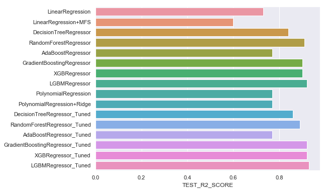

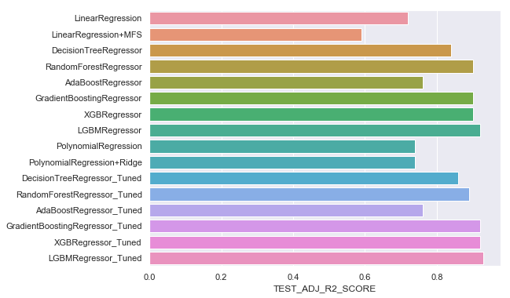

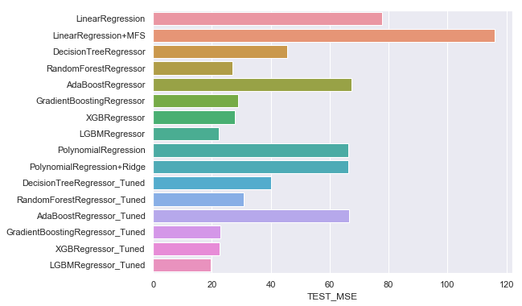

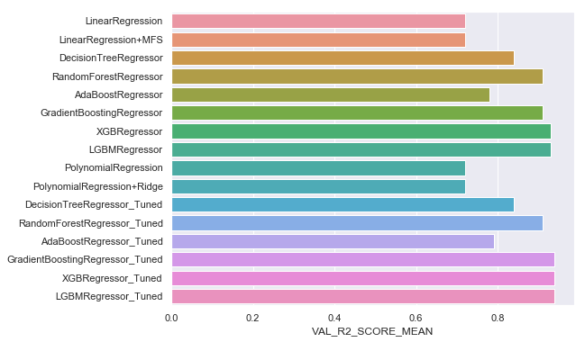

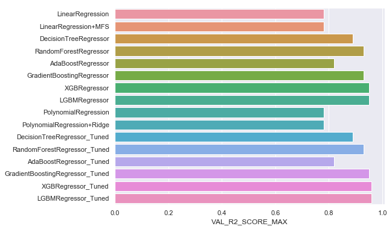

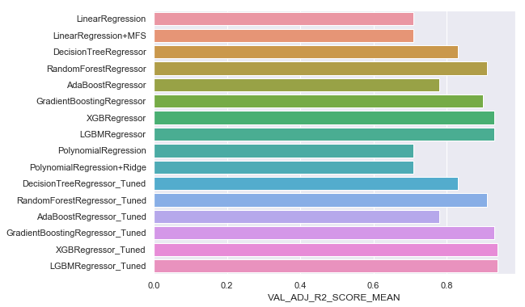

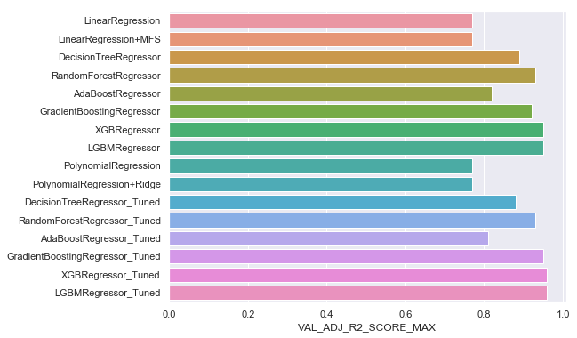

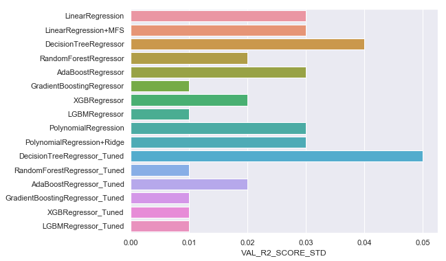

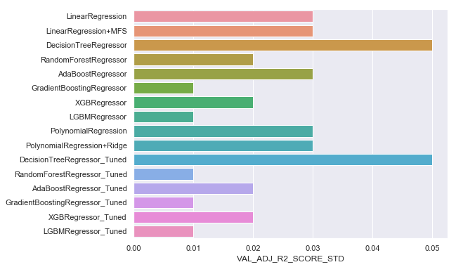

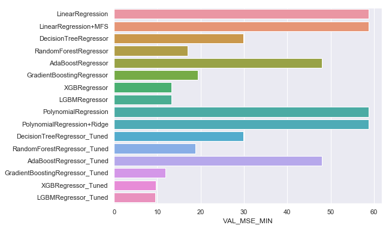

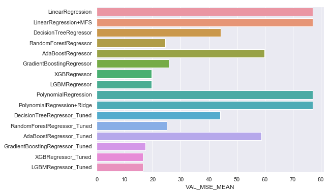

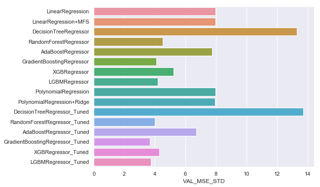

[3 more figures not shown]

```python
# To retrieve the best model for each metric and its corresponding value for it
for i in ['TEST_R2_SCORE','TEST_ADJ_R2_SCORE','VAL_R2_SCORE_MEAN','VAL_R2_SCORE_MAX','VAL_ADJ_R2_SCORE_MEAN','VAL_ADJ_R2_SCORE_MAX']:
    print("Metric: ",i)
    print("Highest value is: ",modr_df[i].sort_values(ascending=False).head(1)[0],"and present for below models:")
    print(modr_df[modr_df[i]==float(modr_df[i].sort_values(ascending=False).head(1))][i].index.values)
    print("-------------------------------------------------------------------------------------------------------")
for i in ['TEST_MSE','VAL_R2_SCORE_STD','VAL_ADJ_R2_SCORE_STD','VAL_MSE_MIN','VAL_MSE_MEAN','VAL_MSE_STD','VAL_R2_SCORE_COV','VAL_ADJ_R2_SCORE_COV','VAL_MSE_COV']:
    print("Metric: ",i)
    print("Lowest value is: ",modr_df[i].sort_values(ascending=True).head(1)[0],"and present for below models:")
    print(modr_df[modr_df[i]==float(modr_df[i].sort_values(ascending=True).head(1))][i].index.values)
    print("-------------------------------------------------------------------------------------------------------")

# Plots for different metrics
count=0
for i in ['TEST_R2_SCORE','TEST_ADJ_R2_SCORE','TEST_MSE','VAL_R2_SCORE_MEAN','VAL_R2_SCORE_MAX','VAL_ADJ_R2_SCORE_MEAN','VAL_ADJ_R2_SCORE_MAX','VAL_R2_SCORE_STD','VAL_ADJ_R2_SCORE_STD','VAL_MSE_MIN','VAL_MSE_MEAN','VAL_MSE_STD','VAL_R2_SCORE_COV','VAL_ADJ_R2_SCORE_COV','VAL_MSE_COV']:
    count=count+1
    plt.figure(count,figsize=(8,6))
    sns.barplot(x=modr_df[i], y=modr_df[i].index)
```

#### Conclusion:

By looking at above metrics, both XGBoost and Light GBM performed well.  
However additionally Light GBM has performed well on Test dataset. And also Validation Adjusted R-square score and Coefficient of Variation of MSE is less for Light GBM when compared to XG Boost.  
No. of trees required by Light GBM is less when compared to XG Boost.  
Hence Light GBM with tuned hyper-parameter is the best model to predict the strength of Concrete.

#### Confidence Interval

```python
print("R-square score of Light GBM regressor for 95% Confidence Interval is in between:",
      modr_df.loc['LGBMRegressor_Tuned']['VAL_R2_SCORE_5%']*100," and ",modr_df.loc['LGBMRegressor_Tuned']['VAL_R2_SCORE_95%']*100)
print("Adjusted R-square score of Light GBM regressor for 95% Confidence Interval is in between:",
      modr_df.loc['LGBMRegressor_Tuned']['VAL_ADJ_R2_SCORE_5%']*100," and ",modr_df.loc['LGBMRegressor_Tuned']['VAL_ADJ_R2_SCORE_95%']*100)
```

```
R-square score of Light GBM regressor for 95% Confidence Interval is in between: 92.0  and  96.0
Adjusted R-square score of Light GBM regressor for 95% Confidence Interval is in between: 92.0  and  95.0
```